# Assignment 2: Spatial Lag, Spatial Error, and Geographically Weighted Regression

Stephanie Fenniri, Diana Negron, and Kathleen Scopis

2022-11-15

### The following report details statistical methods including Spatial Lag, Spatial Error, and Geographically Weighted Regression.

# Step 1

## Install packages and load in data

```r
options(scipen=999)

#install packages

#install.packages(c("sp", "rgdal", "rgeos", "spdep", "spgwr", "tmap", "spatialreg", "lmtest", "whitestrap", "tseries"))

library(sp)
library(rgdal)
library(rgeos)
library(spdep)
library(spgwr)
library(tmap)
library(spatialreg)
library(whitestrap)
library(lmtest)
library(tseries)

pallete1 <- c("#2596be","#76b5c5","#abdbe3") #blues
pallete2 <- c("#e28743", "#eab676", "#eeeee4") #oranges
pallete3 <- c("#873e23", "#e28743", "#eeeee4") #browns


#read data
shp <- readOGR('C:/Users/kathl/OneDrive/Desktop/Spatial Statistics/Assignment_2/Regression Data')
names(shp@data)
```

```
##  [1] "AREAKEY__"  "AREAKEY"    "Area"       "FID_1"      "POLY_ID"
##  [6] "AREAKEY_1"  "PCTBACHMOR" "MEDHHINC"   "PCTVACANT"  "PCTSINGLES"
## [11] "MEDHVAL"    "LNMEDHVAL"  "LNMEDINC"   "NBelPov100"
```

#1.a ## Present histograms for all variables, then their log transformations Before completing transformation, we must determine which variables reach 0 - these must be increased by 1 before transforming

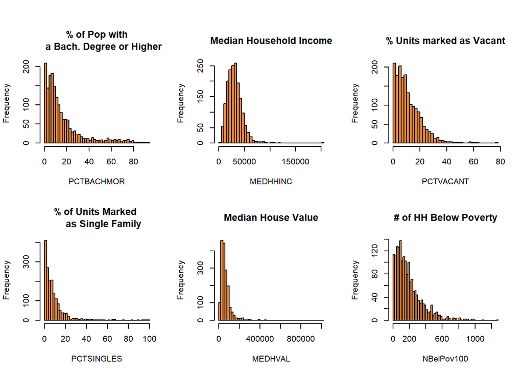

```r
#Histograms of Raw Variables
par(oma=c(0,0,2,0))
par(mfrow=c(2,3))
hist(shp@data$PCTBACHMOR, breaks = 40, col = "#e28743",
     main = "% of Pop with
     a Bach. Degree or Higher",
     xlab = "PCTBACHMOR")
hist(shp@data$MEDHHINC, breaks = 50,col = "#e28743",
     main = "Median Household Income",
     xlab = "MEDHHINC")
hist(shp@data$PCTVACANT, breaks = 40,col = "#e28743",
     main = "% Units marked as Vacant",
     xlab = "PCTVACANT")
hist(shp@data$PCTSINGLES, breaks = 40, col = "#e28743",
     main = "% of Units Marked
     as Single Family",
     xlab = "PCTSINGLES")
hist(shp@data$MEDHVAL, breaks = 50,col = "#e28743",
     main = "Median House Value",
     xlab = "MEDHVAL")
hist(shp@data$NBelPov100, breaks = 50,col = "#e28743",
     main = "# of HH Below Poverty",
     xlab = "NBelPov100")
```

### Which variables have a minimum value of 0?

```r
min(shp$PCTBACHMOR)
```

```
## [1] 0
```

```r
min(shp$MEDHHINC)
```

```
## [1] 2499
```

```r
min(shp$PCTVACANT)
```

```
## [1] 0
```

```r
min(shp$PCTSINGLES)
```

```
## [1] 0
```

```r
min(shp$MEDHVAL)
```

```
## [1] 10000
```

```r
min(shp$NBelPov100)
```

```
## [1] 0
```

## Log Transformations

PCTBACHMOR, PCTVACANT, PCTSINGLES, and NBelPov100 all have minimum values of 0, and must be added to 1 before transforming.

```r
shp@data$Log_MEDHHINC <- log(shp@data$MEDHHINC)
shp@data$Log_MEDHVAL <- log(shp@data$MEDHVAL)

#log transformation +1
shp@data$Log_PCTBACHMOR <- log(shp@data$PCTBACHMOR + 1)
shp@data$Log_PCTVACANT <- log(shp@data$PCTVACANT + 1)
shp@data$Log_PCTSINGLES <- log(shp@data$PCTSINGLES + 1)
shp@data$Log_NBelPov100<- log(shp@data$NBelPov100 + 1)
```

## Histograms of Log Transformed Variables

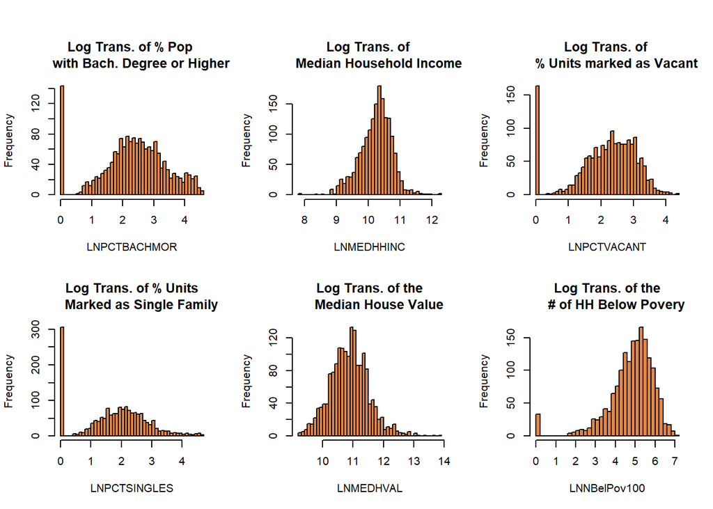

```r
par(oma=c(0,0,2,0))
par(mfrow=c(2,3))
hist(shp@data$Log_PCTBACHMOR, breaks = 40, col = "#e28743",
     main = "Log Trans. of % Pop
     with Bach. Degree or Higher",
     xlab = "LNPCTBACHMOR")
hist(shp@data$Log_MEDHHINC, breaks = 50,col = "#e28743",
     main = "Log Trans. of
     Median Household Income",
     xlab = "LNMEDHHINC")
hist(shp@data$Log_PCTVACANT, breaks = 40,col = "#e28743",
     main = "Log Trans. of
     % Units marked as Vacant",
     xlab = "LNPCTVACANT")
hist(shp@data$Log_PCTSINGLES, breaks = 40, col = "#e28743",
     main = "Log Trans. of % Units
     Marked as Single Family",
     xlab = "LNPCTSINGLES")
hist(shp@data$Log_MEDHVAL, breaks = 50,col = "#e28743",
     main = "Log Trans. of the
     Median House Value",
     xlab = "LNMEDHVAL")
hist(shp@data$Log_NBelPov100, breaks = 50,col = "#e28743",
     main = "Log Trans. of the
     # of HH Below Povery",
     xlab = "LNNBelPov100")
```

# 1.b

## Introducing queen neighbor relationships

```r
queen<-poly2nb(shp, row.names=shp$POLY_ID)
summary(queen)
```

```
## Neighbour list object:
## Number of regions: 1720
## Number of nonzero links: 10526
## Percentage nonzero weights: 0.3558004
## Average number of links: 6.119767
## Link number distribution:
##
##   1   2   3   4   5   6   7   8   9  10  11  12  13  14  15  16  18  27
##   4  16  52 175 348 493 344 177  62  28  10   4   2   1   1   1   1   1
## 4 least connected regions:
## 441 708 1391 1665 with 1 link
## 1 most connected region:
## 1636 with 27 links
```

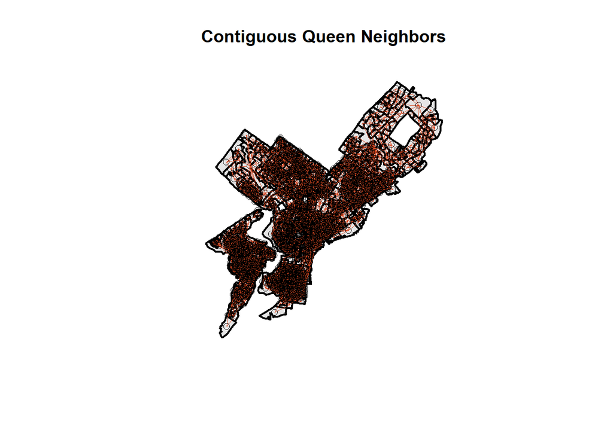

```r
#plot links
plot(shp,
     col='grey90',
     lwd=2
     )
xy<-coordinates(shp)
par(mfrow=c(1,1))
plot(queen,
     xy,
     col='#d74821',
     lwd=.1,
     add=TRUE
     )
title(main='Contiguous Queen Neighbors')
```

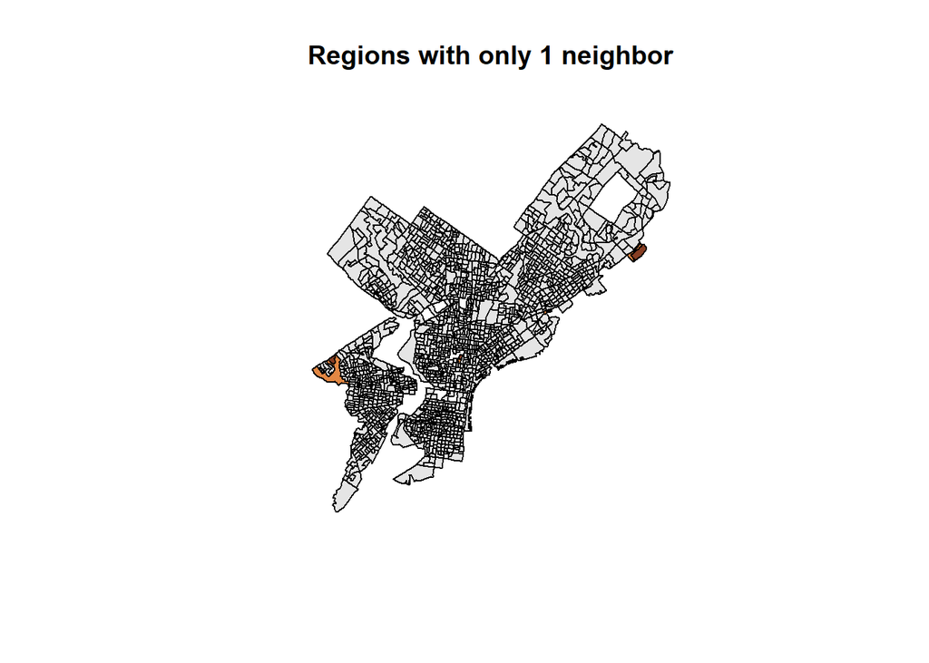

```r
#see which region has only one neighbor
smallestnbcard<-card(queen) #extract neighbor matrix
smallestnb<-which(smallestnbcard == min(smallestnbcard)) #extract block groups with smallest number of neighbors
fg<-rep('grey90', length(smallestnbcard))
fg[smallestnb]<-'#873e23' #color block groups dark orange
fg[queen[[smallestnb[1]]]]<-'#e28743' #color neighboring blocks light orange
fg[queen[[smallestnb[2]]]]<-'#e28743'
fg[queen[[smallestnb[3]]]]<-'#e28743'
fg[queen[[smallestnb[4]]]]<-'#e28743'
plot(shp, col=fg)
title(main='Regions with only 1 neighbor')
```

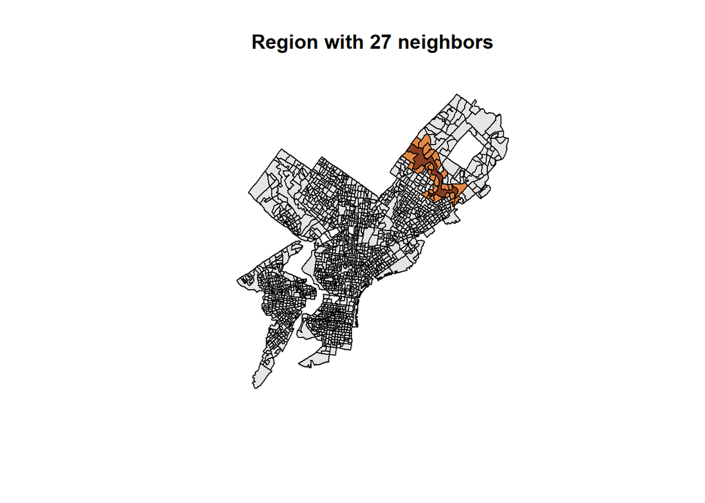

```r
#see which region has most neighbors
largestnbcard<-card(queen)
largestnb<-which(largestnbcard == max(largestnbcard))
fg1<-rep('grey90', length(largestnbcard))
fg1[largestnb]<-'#873e23'
fg1[queen[[largestnb]]]<-'#e28743'
plot(shp, col=fg1)
title(main='Region with 27 neighbors')
```

# 1.c

## Calculate Global Moran’s i using queen weight matrix

It is observed that the Global Moran’s i for LNMedHval is ~0.79.

```r
queenlist<-nb2listw(queen, style = 'W')
moran(shp$Log_MEDHVAL,
      queenlist,
      n=length(queenlist$neighbours),
      S0=Szero(queenlist))$`I`
```

```
## [1] 0.7935638
```

```r
moranMC<-moran.mc(shp$Log_MEDHHINC,
                  queenlist,
                  nsim=999,
                  alternative="two.sided"
                  )  #We use 999 permutations
moranMC
```

```
##
##  Monte-Carlo simulation of Moran I
##
## data:  shp$Log_MEDHHINC
## weights: queenlist
## number of simulations + 1: 1000
##
## statistic = 0.55246, observed rank = 1000, p-value <
## 0.00000000000000022
## alternative hypothesis: two.sided
```

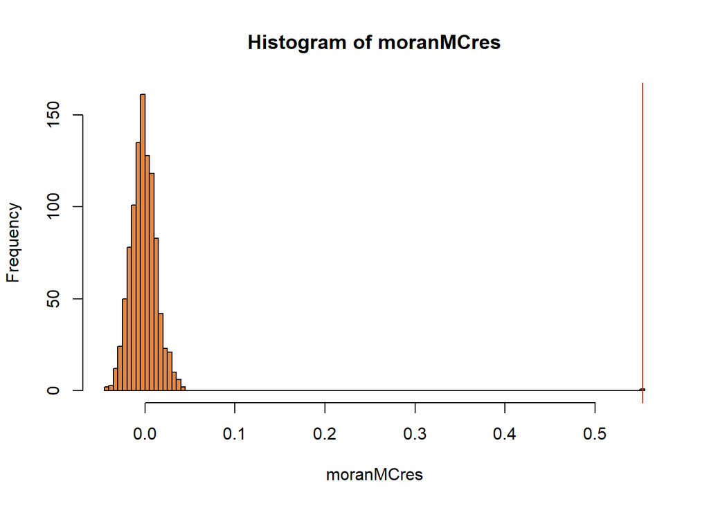

```r
moranMCres<-moranMC$res
hist(moranMCres,
     freq=10000000,
     nclass=100,
     col = "#e28743"
     )   #Draws distribution of Moran's I's calculated from randomly permuted values
# Here, we draw a red vertical line at the observed value of our Moran's I
abline(v=moran(shp$Log_MEDHHINC, queenlist, n=length(queenlist$neighbours), S0=Szero(queenlist))$`I`, col='#c63112')
```

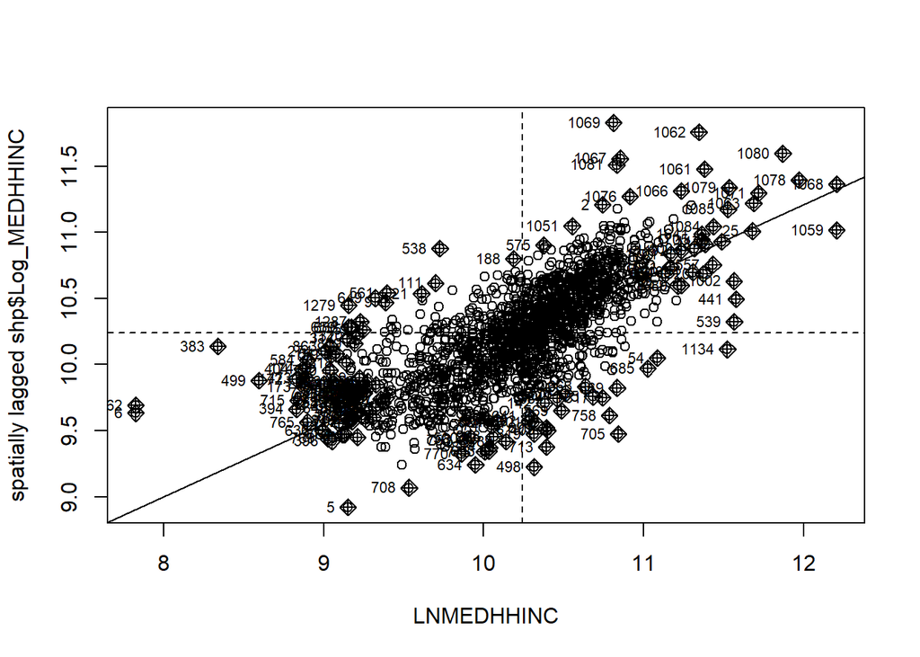

```r
moran.plot(shp$Log_MEDHHINC,
           queenlist,
           xlab = "LNMEDHHINC"
           )
```

# 1.d

## Run Local Moran’s I (LISA - Local Indicator of Spatial Association) analysis using Queen weight matrix.

Is there spatial autocorrelation? let’s check the map… we have also included a spatial association map, which projects areas that have high/high, high/low, low/low, and low/high relationships to their neighboring regions, which helps to describe how typical a block’s value is for its surrounding spatial area.

```r
#Run local moran's I (LISA)
LISA<-localmoran(shp$Log_MEDHVAL,
                 queenlist
                 )
head(LISA)
```

```
##          Ii            E.Ii       Var.Ii     Z.Ii  Pr(z != E(Ii))
## 1 5.3518753 -0.003049782428 1.3051239240 4.687352 0.0000027676336
## 2 4.4121912 -0.002216570245 0.7590386437 5.066879 0.0000004043918
## 3 3.5006316 -0.003049782428 0.7444805191 4.060672 0.0000489316331
## 4 2.4444508 -0.000843876267 0.2410035985 4.981033 0.0000006324567
## 5 1.8834699 -0.001094165811 0.6259058436 2.382080 0.0172151443052
## 6 0.0995037 -0.000001608295 0.0009210143 3.278786 0.0010425472857
```

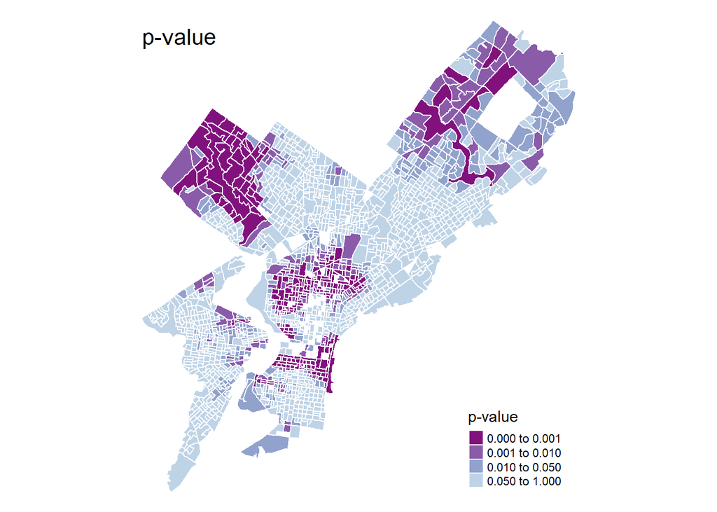

```r
df.LISA <-cbind(shp,
                as.data.frame(LISA)
                )



moranSig.plot<-function(df,listw, title){
  local<-localmoran(x=df$Log_MEDHVAL,
                    listw=listw,
                    zero.policy = FALSE
                    )
  moran.map<-cbind(df, local)
  #Here, col='Pr.z....E.Ii..' is the name of the column in the dataframe df.LISA that we're trying to plot. This variable name might change based on the version of the package.
  tm<-tm_shape(moran.map)+
    tm_borders(col='white')+
    tm_fill(style='fixed',
            col='Pr.z....E.Ii..',
            breaks=c(0,0.001, 0.01, 0.05, 1),
            title= 'p-value',
            palette = '-BuPu')+
    tm_layout(frame = FALSE,
              title = title
              )
  print(tm)
}
moranSig.plot(df.LISA,
              queenlist,
              'p-value'
              )
```

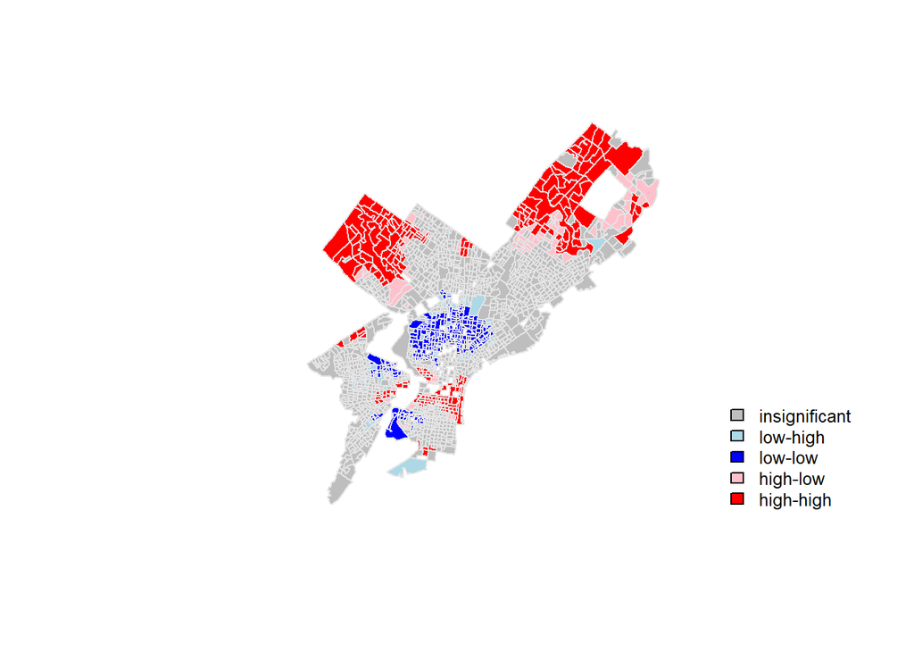

```r
#spatial association map
hl.plot<-function(df, listw){
  local<-localmoran(x=df$Log_MEDHVAL,
                    listw=listw,
                    zero.policy = FALSE
                    )
  quadrant<-vector(mode='numeric',
                   length=323
                   )
  m.prop<-df$Log_MEDHVAL - mean(df$Log_MEDHVAL)
  m.local<-local[,1]-mean(local[,1])
  signif<-0.05
  quadrant[m.prop >0 & m.local>0]<-4 #high MEDHHINC, high clustering
  quadrant[m.prop <0 & m.local<0]<-1 #low MEDHHINC, low clustering
  quadrant[m.prop <0 & m.local>0]<-2 #low MEDHINC, high clustering
  quadrant[m.prop >0 & m.local<0]<-3 #high MEDHHINC, low clustering
  quadrant[local[,5]>signif]<-0

  brks <- c(0,1,2,3,4)
  colors <- c("grey","light blue",'blue','pink',"red")
  plot<-plot(shp,border="gray90",
              lwd=1.0,
             col=colors[findInterval(quadrant,brks,all.inside=FALSE)])
}

hl.plot(shp, queenlist)
legend("bottomright",
       legend=c("insignificant","low-high","low-low","high-low","high-high"),
       fill=c("grey", "light blue", "blue", "pink", "red"),
       bty="n", cex = .8)
```

# 1.e

## OLS Regression

```r
reg<-lm(formula=Log_MEDHVAL ~ Log_NBelPov100 + PCTBACHMOR + PCTSINGLES + PCTVACANT,
        data=shp@data
        )
summary(reg)
```

```
##
## Call:
## lm(formula = Log_MEDHVAL ~ Log_NBelPov100 + PCTBACHMOR + PCTSINGLES +
##     PCTVACANT, data = shp@data)
##
## Residuals:
##      Min       1Q   Median       3Q      Max
## -2.25825 -0.20391  0.03822  0.21744  2.24347
##
## Coefficients:
##                  Estimate Std. Error t value             Pr(>|t|)
## (Intercept)    11.1137661  0.0465330 238.836 < 0.0000000000000002 ***
## Log_NBelPov100 -0.0789054  0.0084569  -9.330 < 0.0000000000000002 ***
## PCTBACHMOR      0.0209098  0.0005432  38.494 < 0.0000000000000002 ***
## PCTSINGLES      0.0029769  0.0007032   4.234            0.0000242 ***
## PCTVACANT      -0.0191569  0.0009779 -19.590 < 0.0000000000000002 ***
## ---
## Signif. codes:  0 '***' 0.001 '**' 0.01 '*' 0.05 '.' 0.1 ' ' 1
##
## Residual standard error: 0.3665 on 1715 degrees of freedom
## Multiple R-squared:  0.6623, Adjusted R-squared:  0.6615
## F-statistic: 840.9 on 4 and 1715 DF,  p-value: < 0.00000000000000022
```

```r
##Prints the log likelihood
#logLik(reg)
##Prints the results of the Breusch-Pagan Test to assess whether heteroscedasticity is present (package: lmtest)
#bptest(reg, studentize=FALSE)
##Prints the results of the Koenker-Bassett Test (also known as the Studentized Breusch-Pagan Test) to assess #whether heteroscedasticity is present (package: lmtest)
#bptest(reg)
##Prints the results of the White Test to assess whether heteroscedasticity is present (package: whitestrap)
#white_test(reg)
##Prints the results of the Jarque-Bera Test to assess whether residuals are normal (package: tseries)
#jarque.bera.test(reg$residuals)
```

# 1.f CHECK

not sure if this section is correct - are these the proper weighted residuals?

## Standardized OLS Residuals (OLS Model residuals divided by an estimate of their standard deviation)

There appears to be some autocorrelation.

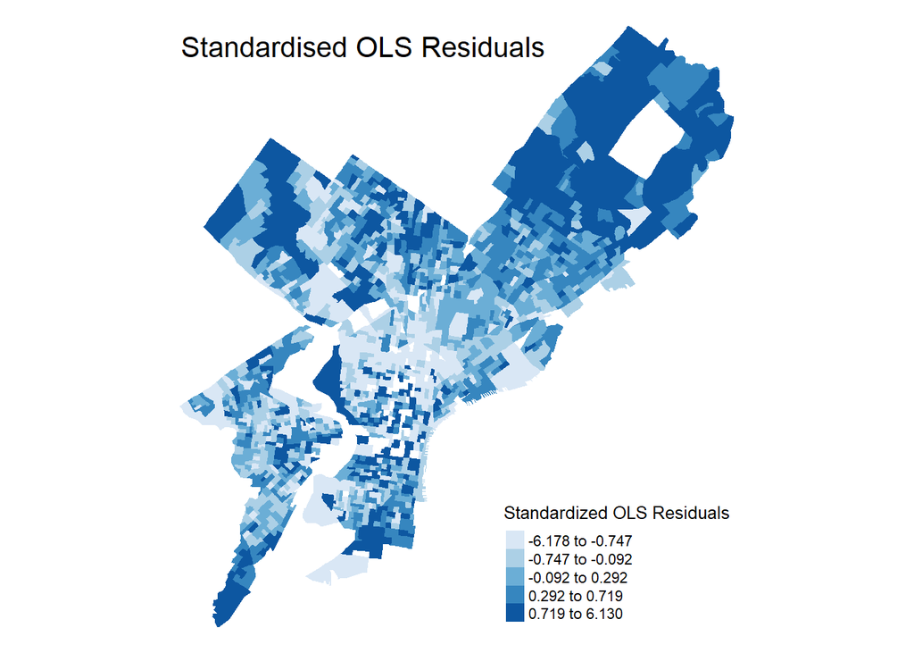

```r
standardised<-rstandard(reg)
resnb<-sapply(queen, function(x) mean(standardised[x]))

shp@data$standardised <- standardised    #creating a new variable in the shapefile shp.
OLS.Residuals.Map<-tm_shape(shp)+
  tm_fill(col='standardised',
          style='quantile',
          title='Standardized OLS Residuals',
          palette ='Blues',
          midpoint = 0
          )  +
  tm_layout(frame=FALSE,
            title = 'Standardised OLS Residuals')

OLS.Residuals.Map
```

Regress the standardized OLS residuals on the spatial lag of the OLS residuals.

```r
#Regressing residuals on their nearest neighbors.
res.lm <- lm(formula=standardised ~ resnb)
summary(res.lm)
```

```
##
## Call:
## lm(formula = standardised ~ resnb)
##
## Residuals:
##     Min      1Q  Median      3Q     Max
## -5.3685 -0.4450  0.0585  0.4618  5.4434
##
## Coefficients:
##             Estimate Std. Error t value            Pr(>|t|)
## (Intercept) -0.01281    0.02121  -0.604               0.546
## resnb        0.73235    0.03244  22.576 <0.0000000000000002 ***
## ---
## Signif. codes:  0 '***' 0.001 '**' 0.01 '*' 0.05 '.' 0.1 ' ' 1
##
## Residual standard error: 0.8793 on 1718 degrees of freedom
## Multiple R-squared:  0.2288, Adjusted R-squared:  0.2283
## F-statistic: 509.7 on 1 and 1718 DF,  p-value: < 0.00000000000000022
```

# 1.g CHECK

## Calculate Moran’s I statistic and a pseudo p-value.

```r
moran.mc(standardised,
         queenlist,
         999,
         alternative="two.sided"
         )
```

```
##
##  Monte-Carlo simulation of Moran I
##
## data:  standardised
## weights: queenlist
## number of simulations + 1: 1000
##
## statistic = 0.3124, observed rank = 1000, p-value < 0.00000000000000022
## alternative hypothesis: two.sided
```

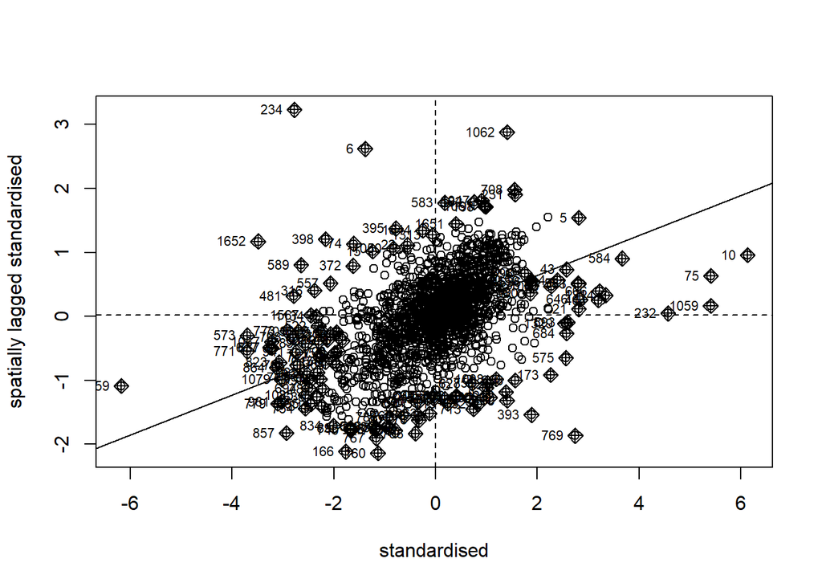

```r
moran.plot(standardised,
           queenlist
           )
```

# 1.h

CHECK BELOW 1.i - IS THIS CORRECT? (MIXED UP SPATIAL LAG AND SPATIAL ERROR)

# 1.i

CHECK - are the spatial lag residual regressions correct? is this the right way to run 999 permutations? ## Spatial Lag Regression

```r
lagreg<-lagsarlm(formula=Log_MEDHVAL ~ Log_NBelPov100 + PCTBACHMOR + PCTSINGLES + PCTVACANT,
                 data=shp@data,
               queenlist
               )
summary(lagreg)
```

```
##
## Call:lagsarlm(formula = Log_MEDHVAL ~ Log_NBelPov100 + PCTBACHMOR +
##     PCTSINGLES + PCTVACANT, data = shp@data, listw = queenlist)
##
## Residuals:
##       Min        1Q    Median        3Q       Max
## -1.655464 -0.117249  0.018654  0.133132  1.726460
##
## Type: lag
## Coefficients: (asymptotic standard errors)
##                   Estimate  Std. Error  z value              Pr(>|z|)
## (Intercept)     3.89844052  0.20111373  19.3843 < 0.00000000000000022
## Log_NBelPov100 -0.03405540  0.00629303  -5.4116         0.00000006246
## PCTBACHMOR      0.00851392  0.00052195  16.3119 < 0.00000000000000022
## PCTSINGLES      0.00203340  0.00051578   3.9424         0.00008068395
## PCTVACANT      -0.00852964  0.00074369 -11.4694 < 0.00000000000000022
##
## Rho: 0.6511, LR test value: 911.51, p-value: < 0.000000000000000222
## Asymptotic standard error: 0.01805
##     z-value: 36.072, p-value: < 0.000000000000000222
## Wald statistic: 1301.2, p-value: < 0.000000000000000222
##
## Log likelihood: -255.7844 for lag model
## ML residual variance (sigma squared): 0.071952, (sigma: 0.26824)
## Number of observations: 1720
## Number of parameters estimated: 7
## AIC: 525.57, (AIC for lm: 1435.1)
## LM test for residual autocorrelation
## test value: 67.739, p-value: 0.00000000000000022204
```

```r
LR.Sarlm(lagreg, reg) #Here lagreg is the SL output; reg is the OLS output
```

```
##
##  Likelihood ratio for spatial linear models
##
## data:
## Likelihood ratio = 911.51, df = 1, p-value < 0.00000000000000022
## sample estimates:
## Log likelihood of lagreg    Log likelihood of reg
##                -255.7844                -711.5376
```

```r
#Prints the results of the Breusch-Pagan Test to assess whether heteroscedasticity is present (package: lmtest)
bptest.Sarlm(lagreg,
             studentize=FALSE
             )
```

```
##
##  Breusch-Pagan test
##
## data:
## BP = 210.76, df = 4, p-value < 0.00000000000000022
```

```r
#Prints the results of the Koenker-Bassett Test (also known as the Studentized Breusch-Pagan Test) to assess whether heteroscedasticity is present (package: lmtest)
bptest.Sarlm(lagreg)
```

```
##
##  studentized Breusch-Pagan test
##
## data:
## BP = 51.412, df = 4, p-value = 0.0000000001831
```

```r
#Prints the results of the Jarque-Bera Test to assess whether residuals are normal (package: tseries)
jarque.bera.test(lagreg$residuals)
```

```
##
##  Jarque Bera Test
##
## data:  lagreg$residuals
## X-squared = 2756.8, df = 2, p-value < 0.00000000000000022
```

```r
# 999 permutations - is this missing something?  is this correct?

reslag<-lagreg$residuals
lagMoranMc<-moran.mc(reslag,
                     queenlist,
                     999,
                     alternative="two.sided"
                     )

lagMoranMc
```

```
##
##  Monte-Carlo simulation of Moran I
##
## data:  reslag
## weights: queenlist
## number of simulations + 1: 1000
##
## statistic = -0.082412, observed rank = 1, p-value = 0.002
## alternative hypothesis: two.sided
```

# 1.j CHECK - MIXED UP SPATIAL LAG AND SPATIAL ERROR

## Spatial Error Regression

```r
errreg<-errorsarlm(formula=Log_MEDHVAL ~ Log_NBelPov100 + PCTBACHMOR + PCTSINGLES + PCTVACANT,
                   data=shp@data,
                   queenlist
                   )
reserr<-residuals(errreg)
errresnb<-sapply(queen,
                 function(x) mean(reserr[x]))
summary(errreg)
```

```
##
## Call:errorsarlm(formula = Log_MEDHVAL ~ Log_NBelPov100 + PCTBACHMOR +
##     PCTSINGLES + PCTVACANT, data = shp@data, listw = queenlist)
##
## Residuals:
##      Min       1Q   Median       3Q      Max
## -1.92652 -0.11541  0.01489  0.13386  1.94867
##
## Type: error
## Coefficients: (asymptotic standard errors)
##                   Estimate  Std. Error  z value              Pr(>|z|)
## (Intercept)    10.90641384  0.05346908 203.9761 < 0.00000000000000022
## Log_NBelPov100 -0.03453480  0.00708951  -4.8712      0.00000110894632
## PCTBACHMOR      0.00981310  0.00072898  13.4614 < 0.00000000000000022
## PCTSINGLES      0.00267790  0.00062085   4.3133      0.00001608343020
## PCTVACANT      -0.00578324  0.00088672  -6.5220      0.00000000006936
##
## Lambda: 0.81492, LR test value: 677.61, p-value: < 0.000000000000000222
## Asymptotic standard error: 0.016373
##     z-value: 49.772, p-value: < 0.000000000000000222
## Wald statistic: 2477.2, p-value: < 0.000000000000000222
##
## Log likelihood: -372.7338 for error model
## ML residual variance (sigma squared): 0.076555, (sigma: 0.27669)
## Number of observations: 1720
## Number of parameters estimated: 7
## AIC: 759.47, (AIC for lm: 1435.1)
```

```r
LR.Sarlm(errreg, reg)
```

```
##
##  Likelihood ratio for spatial linear models
##
## data:
## Likelihood ratio = 677.61, df = 1, p-value < 0.00000000000000022
## sample estimates:
## Log likelihood of errreg    Log likelihood of reg
##                -372.7338                -711.5376
```

```r
#Prints the results of the Breusch-Pagan Test to assess whether heteroscedasticity is present (package: lmtest)
bptest.Sarlm(errreg, studentize=FALSE)
```

```
##
##  Breusch-Pagan test
##
## data:
## BP = 23.213, df = 4, p-value = 0.0001148
```

```r
#Prints the results of the Koenker-Bassett Test (also known as the Studentized Breusch-Pagan Test) to assess whether heteroscedasticity is present (package: lmtest)
bptest.Sarlm(errreg)
```

```
##
##  studentized Breusch-Pagan test
##
## data:
## BP = 5.1627, df = 4, p-value = 0.271
```

```r
#Prints the results of the Jarque-Bera Test to assess whether residuals are normal (package: tseries)
jarque.bera.test(errreg$residuals)
```

```
##
##  Jarque Bera Test
##
## data:  errreg$residuals
## X-squared = 3506.9, df = 2, p-value < 0.00000000000000022
```

```r
errMoranMc<-moran.mc(reserr,
                     queenlist,
                     999,
                     alternative="two.sided"
                     )

errMoranMc
```

```
##
##  Monte-Carlo simulation of Moran I
##
## data:  reserr
## weights: queenlist
## number of simulations + 1: 1000
##
## statistic = -0.094533, observed rank = 1, p-value = 0.002
## alternative hypothesis: two.sided
```

# STEP 2

## GWR - Geographically Weighted Regression

QUESTION: Do we plug in the predictive variables here?

```r
#Setting an adaptive bandwidth

bw<-gwr.sel(formula=Log_MEDHVAL ~ Log_NBelPov100 + PCTBACHMOR + PCTSINGLES + PCTVACANT,
            data=shp,
            method = "aic",
            adapt = TRUE)
```

```
## Bandwidth: 0.381966 AIC: 1278.726
## Bandwidth: 0.618034 AIC: 1334.073
## Bandwidth: 0.236068 AIC: 1209.53
## Bandwidth: 0.145898 AIC: 1115.876
## Bandwidth: 0.09016994 AIC: 1007.348
## Bandwidth: 0.05572809 AIC: 910.4307
## Bandwidth: 0.03444185 AIC: 821.2906
## Bandwidth: 0.02128624 AIC: 737.6009
## Bandwidth: 0.01315562 AIC: 681.6086
## Bandwidth: 0.008130619 AIC: 660.8787
## Bandwidth: 0.005024999 AIC: 714.2598
## Bandwidth: 0.009856269 AIC: 667.0857
## Bandwidth: 0.006944377 AIC: 667.59
## Bandwidth: 0.008427569 AIC: 661.757
## Bandwidth: 0.007677515 AIC: 663.6788
## Bandwidth: 0.008171309 AIC: 660.931
## Bandwidth: 0.00805268 AIC: 661.144
## Bandwidth: 0.008130619 AIC: 660.8787
```

```r
bw
```

```
## [1] 0.008130619
```

## Setting a Fixed Bandwidth

```r
bw_fixed<-gwr.sel(formula=Log_MEDHVAL ~ Log_NBelPov100 + PCTBACHMOR + PCTSINGLES + PCTVACANT,
            data=shp,
            method = "aic",
            adapt = FALSE)
```

```
## Bandwidth: 47374.26 AIC: 1380.178
## Bandwidth: 76576.63 AIC: 1412.408
## Bandwidth: 29326.2 AIC: 1314.513
## Bandwidth: 18171.89 AIC: 1205.472
## Bandwidth: 11278.14 AIC: 1056.874
## Bandwidth: 7017.572 AIC: 904.1873
## Bandwidth: 4384.396 AIC: 773.8975
## Bandwidth: 2757.003 AIC: 701.36
## Bandwidth: 1751.22 AIC: 921
## Bandwidth: 3378.612 AIC: 715.0242
## Bandwidth: 2578.467 AIC: 707.8216
## Bandwidth: 2916.634 AIC: 700.6484
## Bandwidth: 2860.57 AIC: 700.4427
## Bandwidth: 2865.223 AIC: 700.4423
## Bandwidth: 2863.527 AIC: 700.4421
## Bandwidth: 2863.506 AIC: 700.4421
## Bandwidth: 2863.504 AIC: 700.4421
## Bandwidth: 2863.505 AIC: 700.4421
## Bandwidth: 2863.505 AIC: 700.4421
## Bandwidth: 2863.505 AIC: 700.4421
## Bandwidth: 2863.504 AIC: 700.4421
## Bandwidth: 2863.505 AIC: 700.4421
## Bandwidth: 2863.505 AIC: 700.4421
```

```r
bw_fixed
```

```
## [1] 2863.505
```

## Adaptive Bandwidth

```r
gwrmodel<-gwr(formula=Log_MEDHHINC~Log_MEDHVAL+PCTVACANT,
              data=shp,
              adapt = bw, #adaptive bandwidth determined by proportion of observations accounted for
              gweight=gwr.Gauss,
              se.fit=TRUE, #to return local standard errors
              hatmatrix = TRUE)
gwrmodel
```

```
## Call:
## gwr(formula = Log_MEDHHINC ~ Log_MEDHVAL + PCTVACANT, data = shp,
##     gweight = gwr.Gauss, adapt = bw, hatmatrix = TRUE, se.fit = TRUE)
## Kernel function: gwr.Gauss
## Adaptive quantile: 0.008130619 (about 13 of 1720 data points)
## Summary of GWR coefficient estimates at data points:
##                     Min.     1st Qu.      Median     3rd Qu.        Max.
## X.Intercept. -1.62492384  4.30769937  5.73537240  7.19240449 10.94460805
## Log_MEDHVAL  -0.07446270  0.28221101  0.41806650  0.55212360  1.08455590
## PCTVACANT    -0.08581501 -0.00973303 -0.00473283  0.00028396  0.02121667
##               Global
## X.Intercept.  5.6508
## Log_MEDHVAL   0.4316
## PCTVACANT    -0.0092
## Number of data points: 1720
## Effective number of parameters (residual: 2traceS - traceS'S): 218.4288
## Effective degrees of freedom (residual: 2traceS - traceS'S): 1501.571
## Sigma (residual: 2traceS - traceS'S): 0.3187979
## Effective number of parameters (model: traceS): 153.2121
## Effective degrees of freedom (model: traceS): 1566.788
## Sigma (model: traceS): 0.3120925
## Sigma (ML): 0.2978683
## AICc (GWR p. 61, eq 2.33; p. 96, eq. 4.21): 1053.968
## AIC (GWR p. 96, eq. 4.22): 868.1632
## Residual sum of squares: 152.6079
## Quasi-global R2: 0.6323028
```

## Fixed Bandwidth

```r
gwrmodel_fixed<-gwr(formula=Log_MEDHHINC~Log_MEDHVAL+PCTVACANT,
              data=shp,
              bandwidth = bw_fixed, #fixed bandwidth
              gweight=gwr.Gauss,
              se.fit=TRUE, #to return local standard errors
              hatmatrix = TRUE)
gwrmodel_fixed
```

```
## Call:
## gwr(formula = Log_MEDHHINC ~ Log_MEDHVAL + PCTVACANT, data = shp,
##     bandwidth = bw_fixed, gweight = gwr.Gauss, hatmatrix = TRUE,
##     se.fit = TRUE)
## Kernel function: gwr.Gauss
## Fixed bandwidth: 2863.505
## Summary of GWR coefficient estimates at data points:
##                      Min.      1st Qu.       Median      3rd Qu.         Max.
## X.Intercept. -11.60422213   4.20981368   5.72170972   7.15230840  12.57363349
## Log_MEDHVAL   -0.16280395   0.28512826   0.41809353   0.56436665   1.92343805
## PCTVACANT     -0.15049399  -0.00885470  -0.00473414  -0.00051821   0.06389958
##               Global
## X.Intercept.  5.6508
## Log_MEDHVAL   0.4316
## PCTVACANT    -0.0092
## Number of data points: 1720
## Effective number of parameters (residual: 2traceS - traceS'S): 219.3261
## Effective degrees of freedom (residual: 2traceS - traceS'S): 1500.674
## Sigma (residual: 2traceS - traceS'S): 0.322455
## Effective number of parameters (model: traceS): 157.5512
## Effective degrees of freedom (model: traceS): 1562.449
## Sigma (model: traceS): 0.3160162
## Sigma (ML): 0.3011952
## AICc (GWR p. 61, eq 2.33; p. 96, eq. 4.21): 1102.685
## AIC (GWR p. 96, eq. 4.22): 910.7107
## Residual sum of squares: 156.0359
## Quasi-global R2: 0.6240434
```

## GWR Output

```r
summary(gwrmodel$SDF)
```

```
## Object of class SpatialPolygonsDataFrame
## Coordinates:
##         min       max
## x 2660604.8 2750171.3
## y  207610.6  304858.8
## Is projected: TRUE
## proj4string :
## [+proj=lcc +lat_0=39.3333333333333 +lon_0=-77.75 +lat_1=40.9666666666667
## +lat_2=39.9333333333333 +x_0=600000 +y_0=0 +datum=NAD83 +units=us-ft
## +no_defs]
## Data attributes:
##      sum.w        X.Intercept.     Log_MEDHVAL         PCTVACANT
##  Min.   :16.03   Min.   :-1.625   Min.   :-0.07446   Min.   :-0.085815
##  1st Qu.:24.47   1st Qu.: 4.308   1st Qu.: 0.28221   1st Qu.:-0.009733
##  Median :26.64   Median : 5.735   Median : 0.41807   Median :-0.004733
##  Mean   :27.48   Mean   : 5.629   Mean   : 0.42757   Mean   :-0.005790
##  3rd Qu.:29.45   3rd Qu.: 7.192   3rd Qu.: 0.55212   3rd Qu.: 0.000284
##  Max.   :86.70   Max.   :10.945   Max.   : 1.08456   Max.   : 0.021217
##  X.Intercept._se  Log_MEDHVAL_se     PCTVACANT_se          gwr.e
##  Min.   :0.4056   Min.   :0.03587   Min.   :0.002266   Min.   :-2.135873
##  1st Qu.:0.9944   1st Qu.:0.08859   1st Qu.:0.004812   1st Qu.:-0.138334
##  Median :1.4246   Median :0.12996   Median :0.006458   Median : 0.024808
##  Mean   :1.5779   Mean   :0.14253   Mean   :0.007720   Mean   :-0.001443
##  3rd Qu.:2.0049   3rd Qu.:0.18220   3rd Qu.:0.009196   3rd Qu.: 0.175134
##  Max.   :6.2484   Max.   :0.54488   Max.   :0.030986   Max.   : 1.216632
##       pred           pred.se           localR2        X.Intercept._se_EDF
##  Min.   : 9.204   Min.   :0.02809   Min.   :0.05656   Min.   :0.4143
##  1st Qu.: 9.981   1st Qu.:0.05094   1st Qu.:0.24148   1st Qu.:1.0158
##  Median :10.231   Median :0.06077   Median :0.34087   Median :1.4552
##  Mean   :10.245   Mean   :0.06645   Mean   :0.35582   Mean   :1.6118
##  3rd Qu.:10.521   3rd Qu.:0.07619   3rd Qu.:0.45532   3rd Qu.:2.0480
##  Max.   :12.171   Max.   :0.25205   Max.   :0.75141   Max.   :6.3826
##  Log_MEDHVAL_se_EDF PCTVACANT_se_EDF     pred.se.1
##  Min.   :0.03664    Min.   :0.002315   Min.   :0.02870
##  1st Qu.:0.09050    1st Qu.:0.004916   1st Qu.:0.05203
##  Median :0.13275    Median :0.006597   Median :0.06208
##  Mean   :0.14559    Mean   :0.007886   Mean   :0.06788
##  3rd Qu.:0.18612    3rd Qu.:0.009394   3rd Qu.:0.07782
##  Max.   :0.55659    Max.   :0.031652   Max.   :0.25747
```

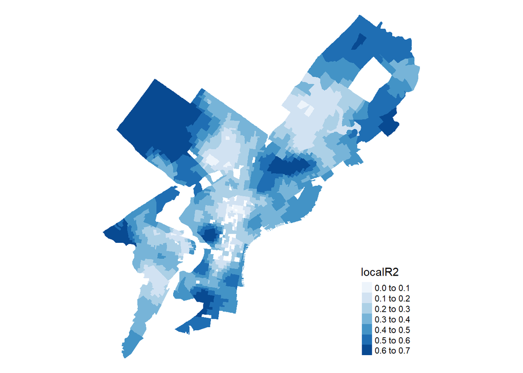

```r
#map standardized coefficients
gwrresults<-as.data.frame(gwrmodel$SDF)
shp$coefLog_MEDHVALst<-gwrresults$Log_MEDHVAL/gwrresults$Log_MEDHVAL_se
shp$coefPCTVACANTst<-gwrresults$PCTVACANT/gwrresults$PCTVACANT_se

shp$gwrE<-gwrresults$gwr.e
shp$localR2<-gwrresults$localR2

coefLog_MEDHVAL<-tm_shape(shp)+
  tm_fill(col='coefLNMEDHVALst',
          breaks=c(-Inf, -6, -4, -2, 0, 2, 4, 6, Inf),
          title='Standardized coefficient of LNMEDHVAL',
          palette ='-RdBu')+
  tm_layout(frame=FALSE,
            title = 'Median House Value (Log)')

coefPCTVACANT<-tm_shape(shp)+
  tm_fill(col='coefPCTVACANTst',
          breaks=c(-Inf, -6, -4, -2, 0, 2, 4, 6, Inf),
          title='Standardized coefficient of PCTVACANT',
          palette='-RdBu')+
  tm_layout(frame=FALSE,
            title = 'Percentage of Housing Vacant')

#tmap_arrange(coefLog_MEDHVAL, coefPCTVACANT, ncol=2)

tm_shape(shp)+
  tm_fill(col='localR2',
          breaks=c(0, 0.1, 0.2, 0.3, 0.4, 0.5, 0.6, 0.7),
          n=5,
          palette = 'Blues')+
  tm_layout(frame=FALSE)
```